[OHI-Northeast](http://www.ohi-northeast.org/) | [OHI Science](http://ohi-science.org) | [Citation policy](http://ohi-science.org/citation-policy/)

# Preparing stock status data layer derived from the RAM database

Compiled on Mon Mar 4 11:28:14 2019 by afflerbach

This script filters the RAM database v4.44 for all stocks in the Northeast region and summarizes the available information for each stock. The output includes stock status and scores for all stocks that are not included in the data shared by NOAA.

# 1 Data Source

**Description**: RAM Legacy Stock Assessment Database provides information on global fish stocks including catch, B/Bmsy and F/Fmsy among other metrics.

**Time range**: pre-1900 to 2016

**Format**: Tabular

# 2 Analysis

What assessment information do we have for these stocks?

```r
#RAM data
assessment_data_file <- file.path(dir_M, 'git-annex/globalprep/_raw_data/RAM/d2019/RLSADB v4.44/DB Files With Assessment Data/DBdata.RData')
load(assessment_data_file)

metadata <- as.data.frame(metadata, stringsAsFactors = FALSE)

#filter metadata from RAM to select only those stocks in the Northeast
ne_stocks <- metadata %>%
  filter(region %in% c("US East Coast", "Atlantic Ocean"),
         areaname != "South Atlantic",
         areaname != "Eastern Atlantic")
```

Bring in a list of the stocks we already have assessment info for from NOAA.

```r
noaa_stock_assess <- read.csv("data/nmfs_stock_scores.csv") %>%
  select(-X) %>%
  separate(stock, into = c("species", "location"), sep = " - ")

unique(noaa_stock_assess$species)
```

```
##  [1] "Acadian redfish"       "American plaice"
##  [3] "Atlantic cod"          "Atlantic halibut"
##  [5] "Atlantic herring"      "Atlantic mackerel"
##  [7] "Atlantic salmon"       "Atlantic surfclam"
##  [9] "Atlantic wolffish"     "Barndoor skate"
## [11] "Black sea bass"        "Bluefish"
## [13] "Butterfish"            "Clearnose skate"
## [15] "Goosefish"             "Haddock"
## [17] "Little skate"          "Longfin inshore squid"
## [19] "Ocean pout"            "Ocean quahog"
## [21] "Pollock"               "Red hake"
## [23] "Rosette skate"         "Scup"
## [25] "Sea scallop"           "Silver hake"
## [27] "Smooth skate"          "Spiny dogfish"
## [29] "Summer flounder"       "Thorny skate"
## [31] "Tilefish"              "White hake"
## [33] "Windowpane"            "Winter flounder"
## [35] "Winter skate"          "Witch flounder"
## [37] "Yellowtail flounder"
```

Compare species in NOAA data with RAM

```r
diff <- setdiff(tolower(ne_stocks$commonname), tolower(noaa_stock_assess$species)) #make all names lowercase to avoide any mismatches due to case
diff
```

```
##  [1] "albacore tuna"           "atlantic bluefin tuna"
##  [3] "atlantic croaker"        "blue crab"
##  [5] "bigeye tuna"             "blue marlin"
##  [7] "atlantic butterfish"     "herring"
##  [9] "northern shortfin squid" "american lobster"
## [11] "atlantic menhaden"       "monkfish"
## [13] "northern shrimp"         "red deepsea crab"
## [15] "sailfish"                "scalloped hammerhead"
## [17] "skipjack tuna"           "smooth dogfish"
## [19] "striped bass"            "swordfish"
## [21] "weakfish"                "white marlin"
## [23] "yellowfin tuna"
```

A couple things to note:

- RAM has monkfish and NOAA has goosefish but these are the same stock
- butterfish is in both but missing “atlantic” in NOAA data
- herring is in both but missing “atlantic” in RAM

So we can remove these three species (monkfish, butterfish and herring) from the RAM data since they are captured in NOAA data

```r
ram_stocks_to_use <- ne_stocks %>%
  mutate(common = tolower(commonname)) %>%
  filter(common %in% diff) %>%
  filter(!common %in% c("monkfish", "atlantic butterfish", "herring"))
```

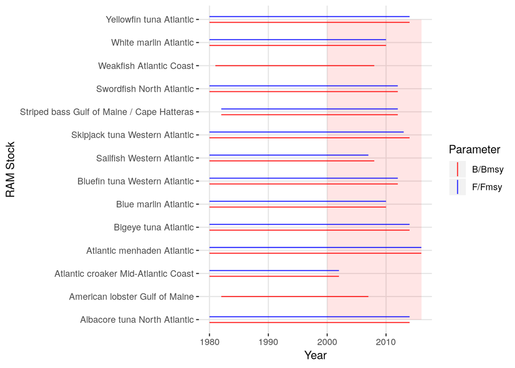

```r
### get time series of B/Bmsy and F/Fmsy for NE stocks from .Rdata
ts <- as.data.frame(timeseries_values_views, stringsAsFactors = FALSE) %>%
  filter(stockid %in% ram_stocks_to_use$stockid) %>%
  select(stockid, stocklong, year, BdivBmsypref, UdivUmsypref) %>%
  filter(!is.na(BdivBmsypref)) %>%
  gather(key = tsid, value = value, -stockid, -stocklong, -year)

span_df <- ts %>%
  filter(!is.na(value)) %>%
  group_by(stocklong, tsid) %>%
  summarize(yr_min = min(year), yr_max = max(year)) %>%
  ungroup() %>%
  mutate(yr_min = ifelse(yr_min < 1980, 1980, yr_min)) %>% ## some stocks have a really long history (e.g. Atlantic Halibut goes back to pre-1900) so I'm reducing the years to only 1980 for plotting purposes
  mutate(metric =
           case_when(
             tsid == "BdivBmsypref" ~ "B/Bmsy",
             tsid == "UdivUmsypref" ~ "F/Fmsy"
           ))

stock_ids <- span_df$stocklong %>% unique()

span_plot <- ggplot(span_df, aes(x = stocklong)) +
  #ggtheme_basic +
  theme(panel.border     = element_blank(),
        panel.grid.minor = element_blank(),
        panel.grid.major = element_line(colour = 'grey90'),
        panel.background = element_blank()) +
  annotate('rect', ymin = 2000, ymax = 2016,
           xmin = first(stock_ids), xmax = last(stock_ids),
           fill = 'red', alpha = .1) +
  geom_linerange(aes(ymin = yr_min, ymax = yr_max,
                     color = metric),
                 position = position_dodge(width = .5), alpha = .8) +
  scale_color_manual(values = c('red', 'blue'),
                       labels=c("B/Bmsy", "F/Fmsy")) +
  coord_flip() +
  labs(x = 'RAM Stock',
       y = 'Year',
       color = 'Parameter')

span_plot
```

# 3 Create layer

```r
#get more species specific information from ne_stocks
sp <- ram_stocks_to_use %>%
  select(stockid, stocklong, scientificname, commonname, areaname) %>%
  distinct()

stock_ass_data <- ts %>%
  mutate(metric =
           case_when(
    tsid == "BdivBmsypref" ~ "B/Bmsy",
    tsid == "UdivUmsypref" ~ "F/Fmsy")) %>%
  select(stockid, stocklong, year, value, metric) %>%
  left_join(sp)

write.csv(stock_ass_data, file = "data/ram_stock_assessment_data.csv")
```

## 3.1 Calculate stock scores

Convert these value to stock scores.

```r
#grab just B/Bmsy data
  ram_b_bmsy <- stock_ass_data %>%
    filter(metric == "B/Bmsy") %>%
    select(stockid, stocklong, scientificname, commonname, year, value) %>%
    rename(b_bmsy = value)

#grab just F/Fmsy data
  ram_f_fmsy <- stock_ass_data %>%
    filter(metric == "F/Fmsy") %>%
    select(stockid, stocklong, scientificname, commonname, year, value)
  ###
  b_bmsy_underexploit_penalty <- 0.25
  b_bmsy_underexploit_thresh  <- 3.00
  f_fmsy_underfishing_penalty <- 0.25
  f_fmsy_overfishing_thresh   <- 2.00

  ### Apply rolling mean to F/Fmsy
  ## Why do we do this? because B is a less sensitive metric (relies of biological processes) and F can fluctuate pretty easily because it is really just a mgmt decision.
  ram_f_fmsy <- ram_f_fmsy %>%
    mutate(f_fmsy= value) %>%
    arrange(stockid, year) %>%
    group_by(stockid) %>%
    mutate(f_fmsy_rollmean = zoo::rollmean(f_fmsy, k = 3, align = 'right', fill = NA)) %>%
    ungroup() %>%
    select(-value, -f_fmsy) %>%
    rename(f_fmsy = f_fmsy_rollmean)

  stock_status_layers <- ram_b_bmsy %>%
    full_join(ram_f_fmsy)

########################################################.
##### run each fishery through the Kobe plot calcs #####
########################################################.
### * ram_b_bmsy, ram_f_fmsy


### Function for converting B/Bmsy values into a 0 - 1 score
  rescale_bprime_crit <- function(fish_stat_df,
                                  bmax, bmax_val) {

    ###using NOAA's limits here
    overfished_th  <- 0.8
    ###
    underfished_th <- 1.2

    bmax_adj <- (bmax - underfished_th) / (1 - bmax_val) + underfished_th
    ### this is used to create a 'virtual' B/Bmsy max where score drops
    ### to zero.  If bmax_val == 0, this is bmax; if bmax_val > 0, bmax_adj
    ### extends beyond bmax, to create a gradient where bmax_val occurs at bmax.

    fish_stat_df <- fish_stat_df %>%
      # group_by(stock) %>% ### grouping by stock will set b_max by max per stock, instead of max overall
      mutate(b_max     = max(b_bmsy, na.rm = TRUE)) %>%
      ungroup() %>%
      mutate(bPrime = NA,
             bPrime = ifelse(b_bmsy < overfished_th,  ### overfished stock
                             b_bmsy / overfished_th,
                             bPrime),
             bPrime = ifelse(b_bmsy >= overfished_th & b_bmsy < underfished_th,
                             1,                       ### appropriately fished stock
                             bPrime),
             bPrime = ifelse(b_bmsy >= underfished_th,
                             (bmax_adj - b_bmsy) / (bmax_adj - underfished_th), ### underfished stock
                             bPrime),
             bPrime = ifelse(bPrime < 0, 0, bPrime))
    return(fish_stat_df)
  }


  ### Function to create vertical gradient based on distance from
  ### ideal F/Fmsy value to actual F/Fmsy value
  f_gradient <- function(f, over_f, under_f, fmax, fmin_val) {
    x <- ifelse(f < over_f & f > under_f, 1, NA)
    x <- ifelse(f <= under_f, (f * (1 - fmin_val) / under_f + fmin_val), x)
    x <- ifelse(f >= over_f,  (fmax - f) / (fmax - over_f), x)
    x <- ifelse(f > fmax, NA, x)
    return(x)
  }

  ### Function to convert F/Fmsy values into 0 - 1 score
  rescale_fprime_crit <- function(fish_stat_df,
                                  fmax, fmin_val) {

    ### params - taken from BC but changed Bcrit to 0 instead of 0.4:
    Bcrit <- 0.5; overfished_th <- 0.8
    ### underfishing_th is set to the idea "1/3 for the birds":
    underfishing_th <- 0.66; overfishing_th  <- 1.2

    bcritslope = 1 / (overfished_th - Bcrit)
    ### connecting from (Bcrit, 0) to (overfished_th, 1)

    fish_stat_df <- fish_stat_df %>%
      mutate(fPrime = ifelse(b_bmsy < overfished_th & f_fmsy < fmax,
                             f_gradient(f_fmsy + (overfished_th - b_bmsy) * bcritslope,
                                        over_f = overfishing_th,
                                        under_f = underfishing_th,
                                        fmax = fmax,
                                        fmin_val = fmin_val),
                             NA),
             fPrime = ifelse(b_bmsy >= overfished_th & f_fmsy < fmax,
                             f_gradient(f_fmsy,
                                        over_f = overfishing_th,
                                        under_f = underfishing_th,
                                        fmax = fmax,
                                        fmin_val = fmin_val),
                             fPrime),
             fPrime = ifelse(is.na(fPrime), 0, fPrime), ### fill zeros everywhere unscored
             fPrime = ifelse(is.na(f_fmsy), NA, fPrime) ### but if no f_fmsy, reset to NA
      )
    return(fish_stat_df)
  }

  stock_status_df <- stock_status_layers %>%
    rescale_bprime_crit(bmax     = b_bmsy_underexploit_thresh,
                        bmax_val = b_bmsy_underexploit_penalty) %>%
    rescale_fprime_crit(fmax     = f_fmsy_overfishing_thresh,
                        fmin_val = f_fmsy_underfishing_penalty) %>%
    mutate(x_prod = ifelse(!is.na(fPrime), (fPrime * bPrime), bPrime),
           basis  = case_when(
             !is.na(fPrime) & !is.na(bPrime) ~ 'F_Fmsy, B_Bmsy',
             is.na(fPrime)  & !is.na(bPrime) ~ 'B_Bmsy only',
             is.na(bPrime)  & !is.na(fPrime) ~ 'F_Fmsy only'
           )) %>%
    dplyr::select(year, stockid, stocklong, scientificname, commonname,
                  score = x_prod,
                  basis,
                  bPrime, fPrime,
                  b_bmsy, f_fmsy)
```

Remove stocks with just F_Fmsy - these stocks have no stock scores since we don’t have a way to get a score from just F/Fmsy. Also roll all values forward to 2017.

```r
stock_scores <- stock_status_df %>%
  filter(year > 2000,
         basis != "F_Fmsy only") %>%
  group_by(commonname, stocklong, year) %>%
  mutate(score = mean(score, na.rm = T)) %>%
  select(year, commonname, stocklong, score, bPrime, fPrime, b_bmsy, f_fmsy, basis) %>%
  complete(year = 2000:2017) %>% #NOAA catch data only goes to 2016
  distinct() %>%
  mutate(gapfilled = ifelse(is.na(score), 1, 0)) %>%
  group_by(commonname, stocklong) %>%
  fill(score, bPrime, fPrime, b_bmsy, f_fmsy, basis, gapfilled) %>%                #assigns most recent value to following years if missing, up to 2017
  fill(score, bPrime, fPrime, b_bmsy, f_fmsy, basis, gapfilled, .direction = "up") #assigns values to earlier years if missing

write.csv(stock_scores, file = "data/ram_stock_scores.csv")
```

## 3.2 Visualize

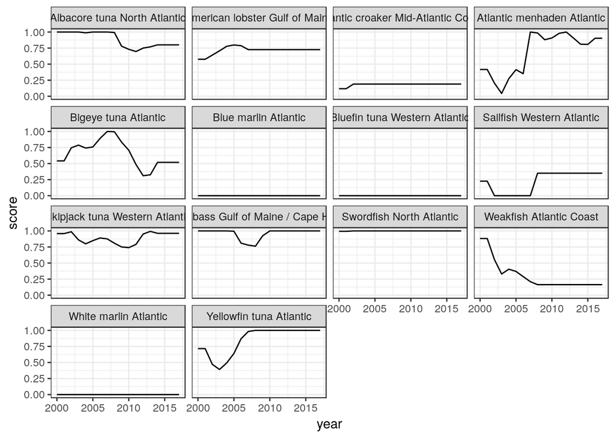

```r
ggplot(stock_scores, aes(x = year, y = score)) +
  geom_line() +
  theme_bw() +
  facet_wrap(~stocklong)
```

```r
kobe_plot <- function(sp){

 ss_df <- stock_scores %>%
    filter(stocklong == sp) %>%
    arrange(year) %>%
    mutate(last_bbmsy = last(b_bmsy),
           last_ffmsy = last(f_fmsy),
           last_datayear = last(year)) %>%
   ungroup()

generate_kobe_df <- function(f_fmsy_max = 2.5,
                             b_bmsy_max = 3.0,
                             reso       = 0.01,
                             bmax_val   = 0,
                             fmin_val   = 0,
                             weighting_b = 1) {

  kobe_raw <- data.frame(stock  = 1,
                     f_fmsy = rep(seq(0, f_fmsy_max, reso), each  = round(b_bmsy_max/reso) + 1),
                     b_bmsy = rep(seq(0, b_bmsy_max, reso), times = round(f_fmsy_max/reso) + 1))

  kobe <- kobe_raw %>%
    rescale_bprime_crit(bmax = b_bmsy_underexploit_thresh,
                        bmax_val = bmax_val) %>%
    rescale_fprime_crit(fmax = f_fmsy_overfishing_thresh,
                        fmin_val = fmin_val) %>%
    mutate(x_geom  = (fPrime * bPrime),
           x_arith = (fPrime + bPrime) / 2)

  return(kobe)
}

bbmsy_lim <- max(round(max(ss_df$b_bmsy, na.rm = TRUE) + .1, 1), 3)
ffmsy_lim <- max(round(max(ss_df$f_fmsy, na.rm = TRUE) + .1, 1), 2.5)

kobe_df <- generate_kobe_df(f_fmsy_max = ffmsy_lim,
                           b_bmsy_max = bbmsy_lim,
                           bmax_val = .25,
                           fmin_val = .25)


kobe_stock_plot <- ggplot(data = kobe_df, aes(x = b_bmsy, y = f_fmsy)) +
    theme_bw() +
    geom_raster(alpha = .8, aes(fill = x_geom)) +
    scale_fill_distiller(palette = 'RdYlGn', direction = 1) +
    labs(title = as.character(sp),
         x = 'B/Bmsy',
         y = 'F/Fmsy',
         fill = "Stock score") +
    geom_path(data = ss_df,
              show.legend = FALSE,
              aes(x = b_bmsy, y = f_fmsy, group = sp),
              color = 'grey30') +
    geom_point(data = ss_df,
               show.legend = FALSE,
              aes(x = last_bbmsy, y = last_ffmsy)) +
    geom_text(data = ss_df %>%
                mutate(year = ifelse(year/5 == round(year/5) | year == last_datayear, year, NA)),
              aes(x = b_bmsy, y = f_fmsy, label = year),
              hjust = 0, nudge_x = .05, size = 2)

return(kobe_stock_plot)
}
```

Apply function to all species in the stock_scores data frame. This does not work for the sub-stock species so we need to remove those.

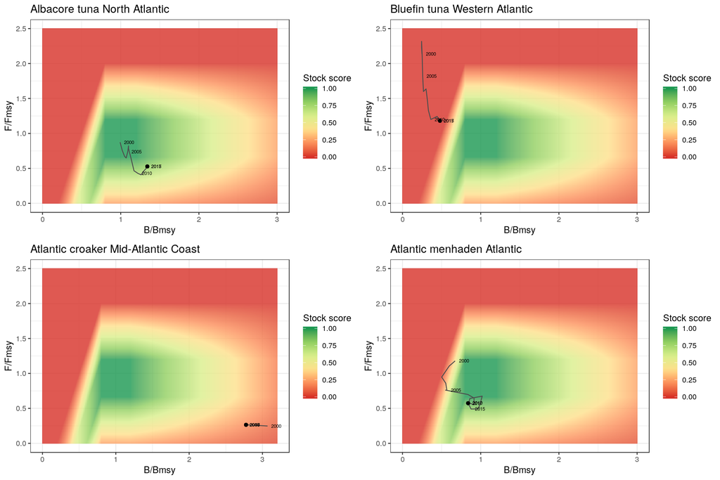

```r
sp <- stock_scores %>%
  filter(basis == "F_Fmsy, B_Bmsy")

plots <- lapply(unique(sp$stocklong), kobe_plot)
cowplot::plot_grid(plotlist = plots[1:4])
```

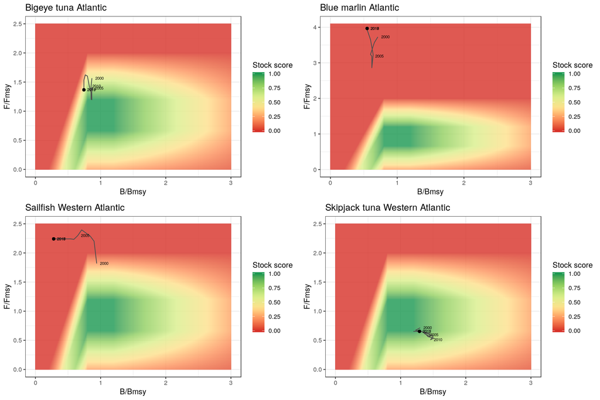

```r
cowplot::plot_grid(plotlist = plots[5:8])
```

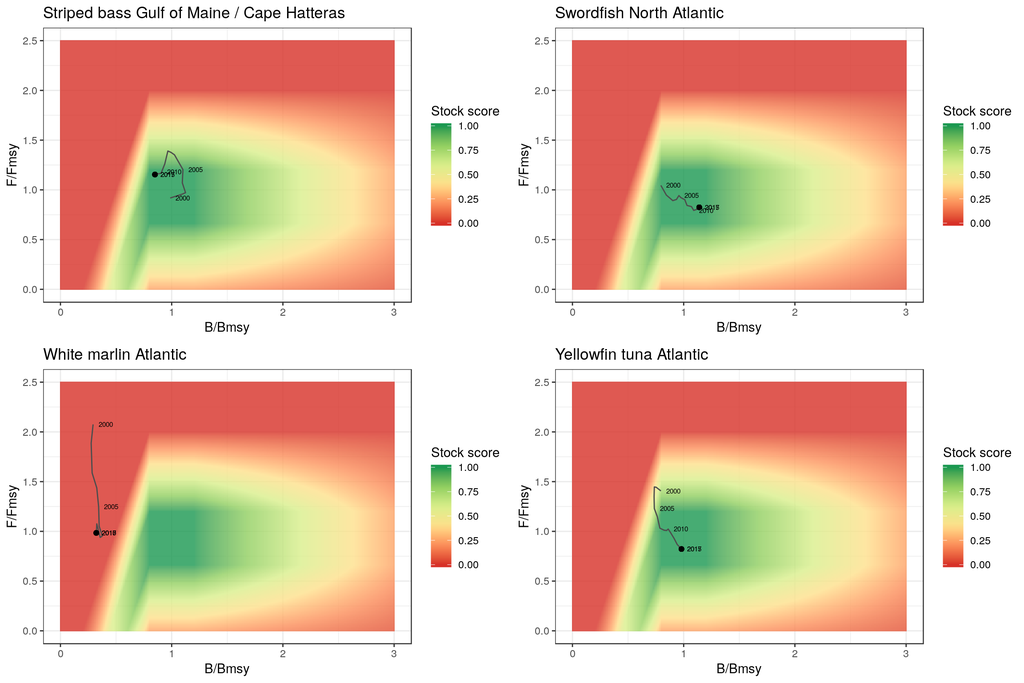

```r
cowplot::plot_grid(plotlist = plots[9:12])
```

```r
cowplot::plot_grid(plotlist = plots[13:15])
```

```r
write.csv(stock_scores, file = "data/ram_stock_scores.csv")
```